# London Cycle Hires and Weather

My goal is to investigate usage of the London cycle hire scheme, and in particular how it varies with the weather. I'm running an analysis from July 2013 to June 2014.

I'm using two data sets here. Daily weather data comes from [Weather Underground](http://www.wunderground.com/history/airport/EGLL/2013/7/1/CustomHistory.html?dayend=30&monthend=6&yearend=2014&req_city=&req_state=&req_statename=&reqdb.zip=&reqdb.magic=&reqdb.wmo=), using the weather station at London Heathrow airport.

(London City Airport is closer to the bike stations that I use, but the data from that airport reports 0 precipitation on every single day. The data from Heathrow seems to be more complete, and I expect it to be almost as relevant.)

I collected the cycle hire data myself, over the course of the year, by downloading CSV files from an [unofficial API](http://borisapi.heroku.com) which now appears to be defunct. It has a granularity of about ten minutes. That's about 50,000 entries per docking station for the year, so for this analysis, I'm only using the data from four docking stations near my office.

All data and source code used for this project can be found in the [git repository](https://github.com/ChickenProp/cycle-hire-weather).

## Exploring the weather data

#### Temperature

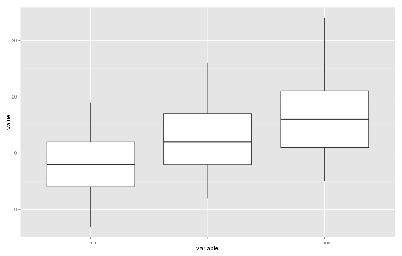

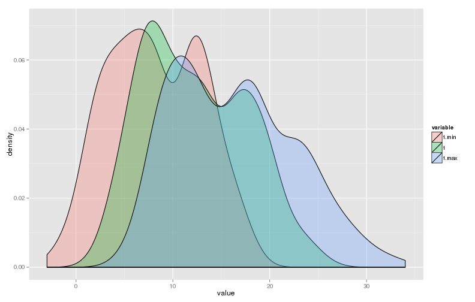

These variables measure the minimum, average, and maximum daily temperatures. The graphs all look similar, and overlap a lot. The shape is a little surprising, as I didn't expect the density graphs to be bimodal. It could potentially be caused by significant differences between summer and winter, with an abrupt shift between the two.

#### Rainfall

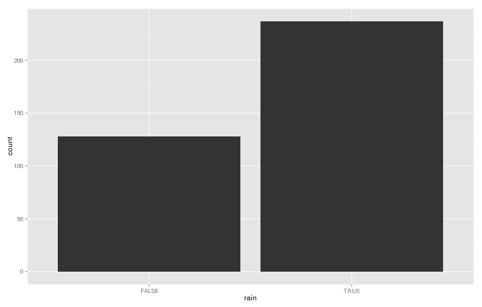

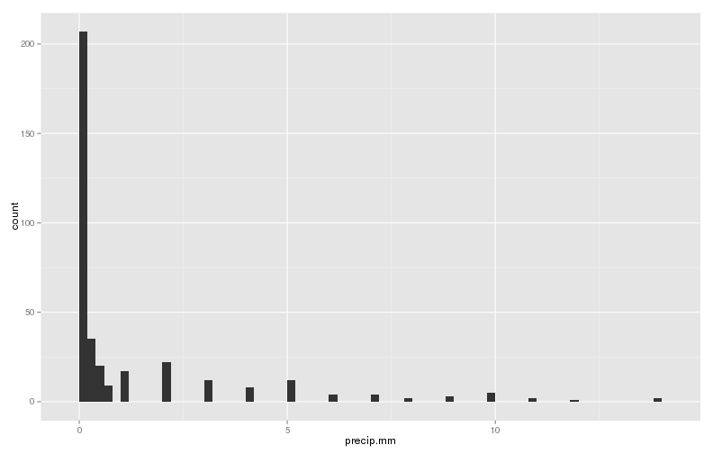

According to the `rain` column, There are over 225 rainy days and only about 125 non-rainy days. But by far the most common bin for `precip.mm` is the leftmost one. Table of values of `precip.mm`:

```
##
##     0  0.25  0.51  0.76  1.02  2.03  3.05  4.06  5.08   6.1  7.11  7.87
##   207    35    20     9    17    22    12     8    12     4     4     2
##  8.89  9.91 10.92 11.94 13.97
##     3     5     2     1     2
```

Although more than half of observations have `rain == TRUE`, more than half of them also have `precip.mm == 0`, which needs more investigation. Rainfall as measured by `precip.mm` versus as measured by `rain`:

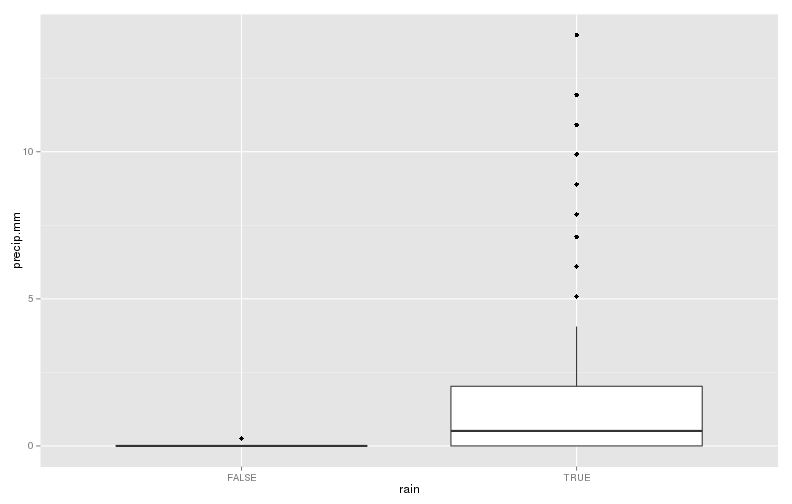

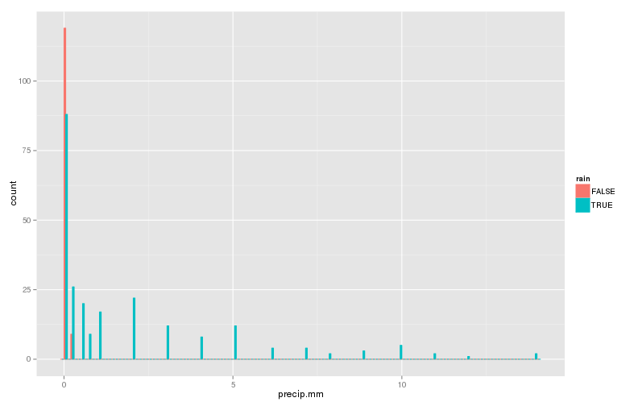

The two measures don't always agree. Sometimes `rain` is false but `precip.mm` is nonzero; and often `rain` is true but `precip.mm` is zero. Neither of those is surprising individually: if `rain` is only counted when the rainfall exceeds a certain threshold, then that threshold could be large (giving false/nonzero) or small (giving true/zero). But the combination suggests that that isn't what's going on, and I don't know what is.

This table counts the anomalies by turning `precip.mm` into a boolean zero/nonzero (false/true) and comparing it to `rain`:

```
##
##         FALSE TRUE
##   FALSE   119    9
##   TRUE     88  149
```

There are 88 instances of true/zero, 9 instances of false/nonzero, but the cases where they agree are the most common.

I find `precip.mm` to me more plausible here. I feel like fewer than half of days are rainy. [This website](http://www.london.climatemps.com/) agrees with me, saying that on average, 164 days out of the year are rainy (`rain` - 237, `precip.mm` - 158).

#### Wind

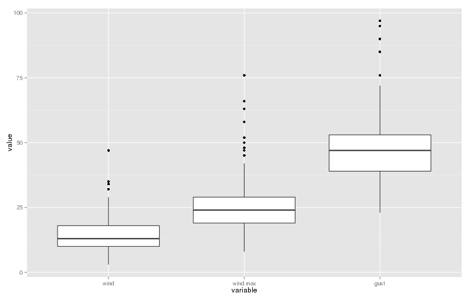

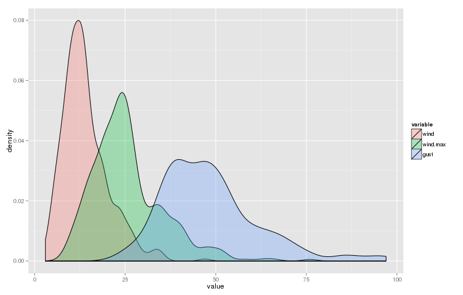

These three measures of wind speed are all averages. `wind` is simply the average wind speed over a day. `wind.max` is the daily maximum of the average wind speed over a short time period (I think one minute). `gust` is the same thing, but with a shorter time period (I think 14 seconds).

Unlike with temperature, the three measures look different. All are right-skewed, although `gust` looks less so. There are several outliers (the isolated points on the box plots), and the quartiles don't overlap. The minimum gust speed (about 24) is almost as high as the median `wind.max`.

## Exploring the bike data

#### Time between updates

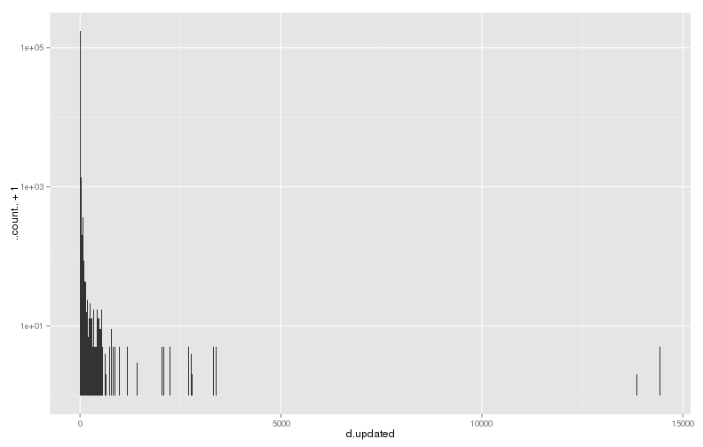

There are a few outliers here. Not all the lines are visible due to rendering artifacts, but above 5000, we only have five entries:

```
##                     name        prev.updated             updated
## 46779    Earnshaw Street 2013-10-03 08:50:23 2013-10-13 09:20:28
## 46899  Southampton Place 2013-10-03 08:50:22 2013-10-13 09:20:27
## 46918       High Holborn 2013-10-03 08:50:24 2013-10-13 09:20:30
## 47049         Bury Place 2013-10-03 08:50:26 2013-10-13 09:20:32
## 175705 Southampton Place 2014-06-20 17:36:06 2014-06-30 08:30:03
```

The first four of these happened when my collection script broke and I failed to realize it. The other occurred when Southampton Place was taken out of service temporarily.

Let's zoom in on the lower ones:

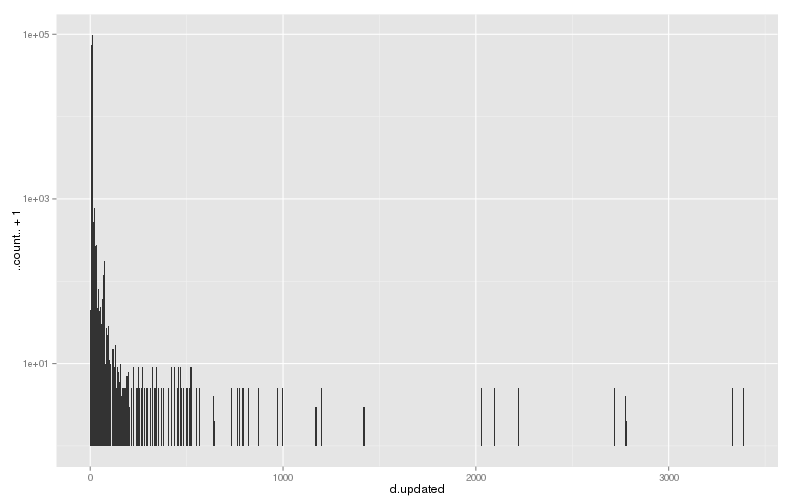

There are several instances where the time between updates is unusually large, on the order of hours or days. The times of entries with between 2000 and 5000 minutes between updates:

```
##                     name        prev.updated             updated
## 32650       High Holborn 2013-08-31 15:10:07 2013-09-02 12:30:05
## 32660         Bury Place 2013-08-31 15:10:08 2013-09-02 12:30:07
## 32672  Southampton Place 2013-08-31 15:10:05 2013-09-02 12:30:04
## 32674    Earnshaw Street 2013-08-31 15:10:06 2013-09-02 12:30:05
## 38546       High Holborn 2013-09-14 22:39:00 2013-09-16 08:24:22
## 38719         Bury Place 2013-09-14 22:39:02 2013-09-16 08:24:23
## 38734  Southampton Place 2013-09-14 22:38:58 2013-09-16 08:24:20
## 38735    Earnshaw Street 2013-09-14 22:38:59 2013-09-16 08:24:21
## 84066         Bury Place 2013-12-27 15:40:08 2013-12-29 23:10:14
## 84069       High Holborn 2013-12-27 15:40:06 2013-12-29 23:10:13
## 84073  Southampton Place 2013-12-27 15:40:05 2013-12-29 23:10:11
## 84078    Earnshaw Street 2013-12-27 15:40:05 2013-12-29 23:10:12
## 84186    Earnshaw Street 2013-12-30 00:10:05 2013-12-31 13:10:07
## 84202       High Holborn 2013-12-30 00:10:06 2013-12-31 13:10:09
## 84269  Southampton Place 2013-12-30 00:10:05 2013-12-31 13:10:06
## 84330         Bury Place 2013-12-30 00:10:07 2013-12-31 13:10:11
## 89443  Southampton Place 2014-01-12 20:20:10 2014-01-14 18:40:07
## 89459       High Holborn 2014-01-12 20:20:13 2014-01-14 18:40:11
## 89467         Bury Place 2014-01-12 20:20:14 2014-01-14 18:40:16
## 89524    Earnshaw Street 2014-01-12 20:20:11 2014-01-14 18:40:09
## 121381   Earnshaw Street 2014-03-15 14:50:06 2014-03-17 01:50:04
## 121398      High Holborn 2014-03-15 14:50:07 2014-03-17 01:50:05
## 121444        Bury Place 2014-03-15 14:50:10 2014-03-17 01:50:07
## 121591 Southampton Place 2014-03-15 14:50:05 2014-03-17 01:50:04
## 133765      High Holborn 2014-04-11 16:59:37 2014-04-14 01:29:07
## 133900   Earnshaw Street 2014-04-11 16:59:36 2014-04-14 01:29:05
## 133961        Bury Place 2014-04-11 16:59:38 2014-04-14 01:29:08
## 134027 Southampton Place 2014-04-11 16:59:35 2014-04-14 01:29:05
```

It looks like these happened to all stations simultaneously, suggesting problems with either my collection script or the API, rather than problems with individual locations.

Entries with less than 60 minutes between updates, no longer on a log scale:

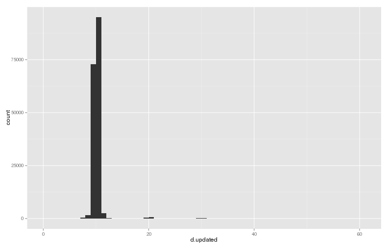

In the vast majority of cases, updates are approximately ten minutes apart. This encourages me to take a subset of the data (`bikes.all` -> `bikes`), considering only entries with `d.updated` less than 15 minutes. This eliminates many outliers in future graphs.

#### Date and time of update

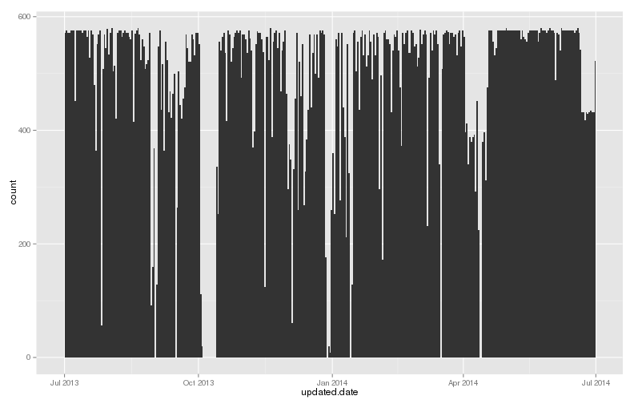

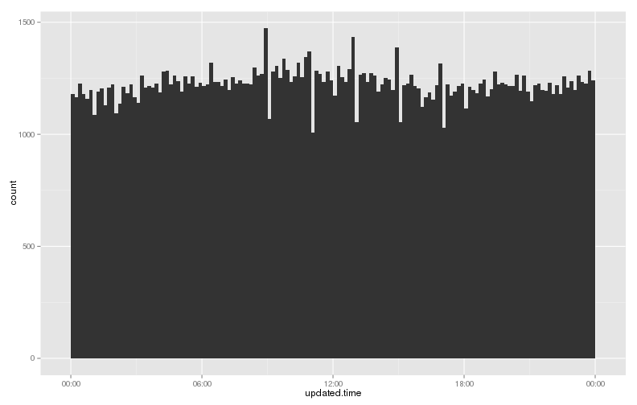

All times of day are approximately equally represented to within ten minutes, which is good. There are five noticeable troughs preceeded by spikes, but they probably don't signify much. Dates are a lot less uniform, however. Even apart from the ten-day period where my script was broken, many days have significantly fewer updates than typical, and some have none at all.

#### Number of days spent with a given number of active docks

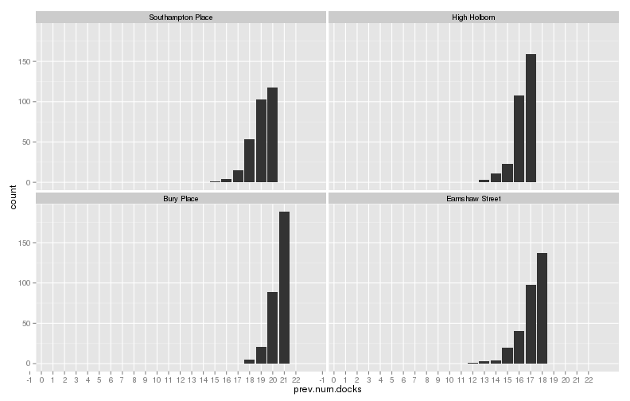

It was common for every station to report less than a full complement of docks. At least two had a full complement for less than half the time (High Holborn and Bury place are unclear in that respect). This isn't surprising, since a bike reported as defective will be locked in, using up a slot but not being available for hire.

#### Journeys taken throughout the year

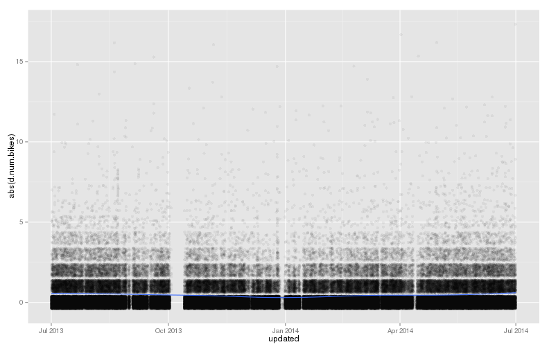

The time of year makes very little difference to the number of rides. There appears to be a slight sinusoidal relationship, but it's very weak. (I didn't do a PMCC test because that assumes that any relationship is linear, which we would naively expect not to be the case here, and also doesn't look true from the graph.)

#### Journeys by weekday

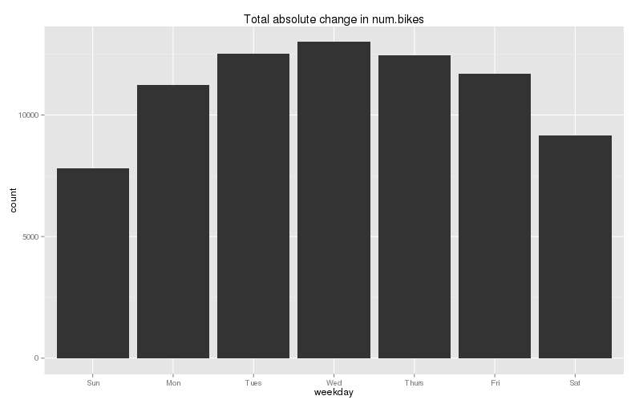

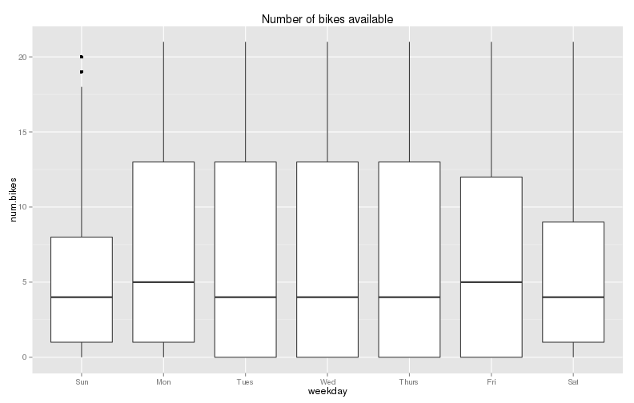

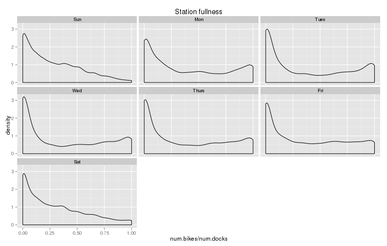

Fewer journeys are taken on weekends. The median number of bikes available doesn't change much throughout the week (5 on monday and friday, 4 on other days), but the distribution does. Saturday and Sunday have noticeably different shapes to the others. They have a single peak, while weekdays are somewhat bimodal, with a small peak where the station is full (probably when people are arriving at work).

(Since the stations have different numbers of docks, I did a graph of fullness rather than of number of bikes. The density plot doesn't show peaks exactly at 0 and 1 because of how the density window works, but histograms of num.bikes and num.spaces show that that's where they are. It would be difficult to use a histogram for this graph because there's no sensible binwidth.)

#### Change in number of bikes between updates

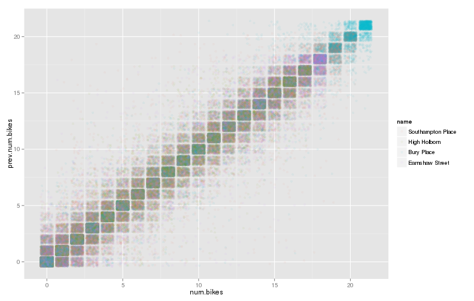

```
##
##  Pearson's product-moment correlation
##
## data:  bikes$num.bikes and bikes$prev.num.bikes
## t = 2466.8, df = 173250, p-value < 2.2e-16
## alternative hypothesis: true correlation is not equal to 0
## 95 percent confidence interval:
##  0.9859301 0.9861908
## sample estimates:
##      cor
## 0.986061
```

There's very strong correlation between the number of bikes in adjacent entries. This is as expected, especially given what we saw about `d.num.bikes` previously. The colors here don't show any particular station-dependent trends.

#### Number of bikes at any given time

[figure not shown]

The correlation also looks strong between the number of bikes at each station at any given time. Since they're all close to each other, that's not surprising. The time is a big factor, with large numbers of bikes in the stations during office hours, and few numbers in the evening and early morning. There's a slight dip around 1pm, which could be related to people using them on their lunch breaks.

This graph gives an overview of global trends, but I mostly use the bikes at specific times. We can zoom in on those:

#### Number of slots available at 0930

(when I'm trying to arrive at work)

This is a proportional frequency plot: within each facet of the graph, the heights of the bins add up to 1. Only weekdays are considered.

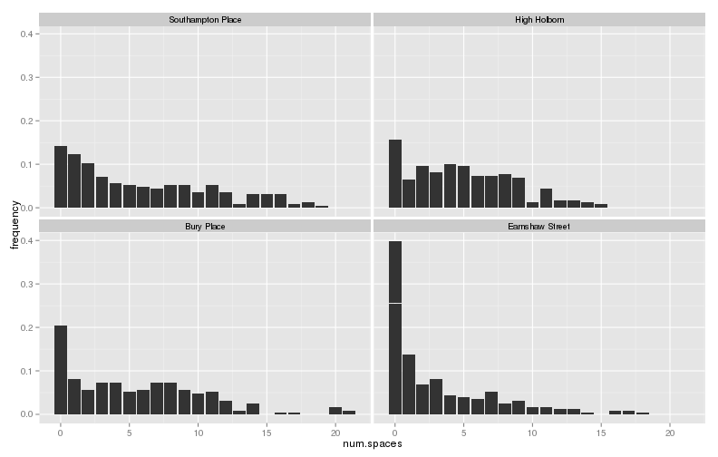

About 40% of the time, Earnshaw street has no spaces. That's actually less than I'd realized. It's directly outside my office, and I haven't even been checking it because I'd assumed it was always full.

#### And at 0940

(in case I'm running late)

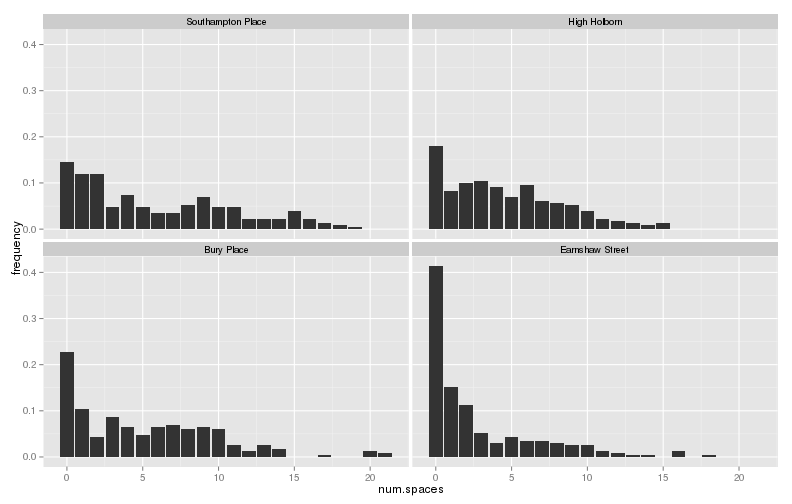

If I'm late, I have slightly less chance of finding a docking station, but not much less.

## Combining the two

#### Journeys taken on rainy vs. non-rainy days

Here, `rain` is the original variable in the dataset, and `rain2` simply measures whether `precip.mm` is nonzero. We have graphs looking at `d.num.bikes` on each type of day, and tables comparing its mean absolute value.

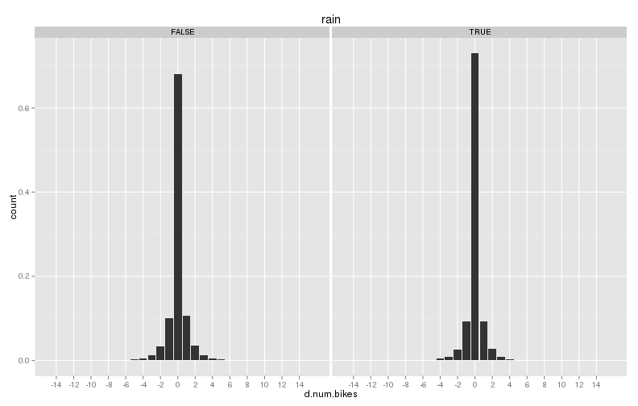

```
## Source: local data frame [2 x 2]
##
##    rain mean(abs(d.num.bikes))
## 1 FALSE              0.5160167
## 2  TRUE              0.4156172
```

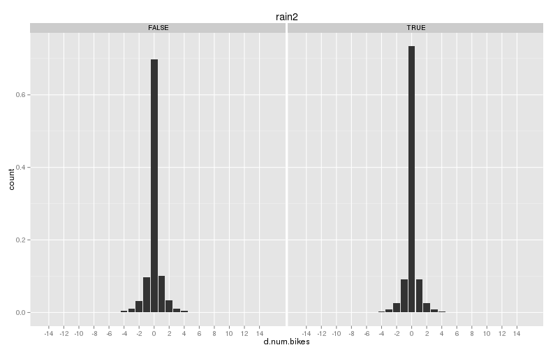

```
## Source: local data frame [2 x 2]
##
##   rain2 mean(abs(d.num.bikes))
## 1 FALSE              0.4824637
## 2  TRUE              0.4073405
```

```
## Source: local data frame [4 x 3]
## Groups: rain
##
##    rain rain2 mean(abs(d.num.bikes))
## 1 FALSE FALSE              0.5184101
## 2 FALSE  TRUE              0.4755501
## 3  TRUE FALSE              0.4351990
## 4  TRUE  TRUE              0.4042656
```

Earlier I said I feel like `precip.mm` is more accurate than `rain`. Despite that, `rain` seems to be capturing something that `precip.mm` doesn't, because bike usage responds slightly more to it. This would seem to suggest that days where `rain` is true but `precip.mm` is zero have less bike usage than average; and indeed this is what we see.

Taking `rain` to be our measure, slightly over 70% of observations had no bikes added or removed on rainy days, and slightly under 70% on non-rainy days. The mean absolute difference is about 25% higher on non-rainy days.

#### Foggy versus non-foggy days

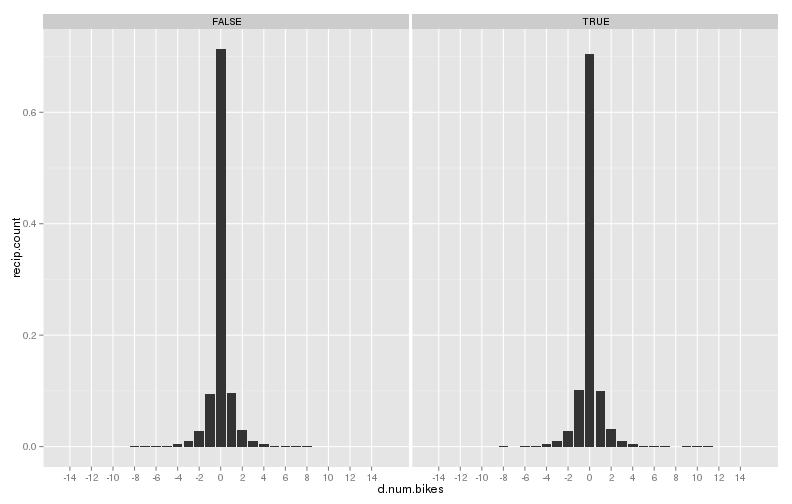

```
## Source: local data frame [2 x 2]
##
##     fog mean(abs(d.num.bikes))
## 1 FALSE              0.4488018
## 2  TRUE              0.4568736
```

#### Journeys by temperature and wind:

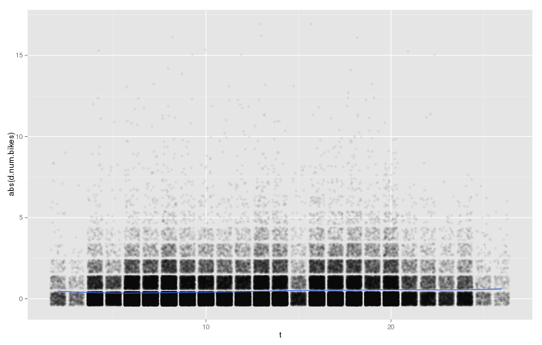

```
##
##  Pearson's product-moment correlation
##
## data:  bikes$t and abs(bikes$d.num.bikes)
## t = 31.414, df = 173250, p-value < 2.2e-16
## alternative hypothesis: true correlation is not equal to 0
## 95 percent confidence interval:
##  0.07057403 0.07993830
## sample estimates:
##        cor
## 0.07525782
```

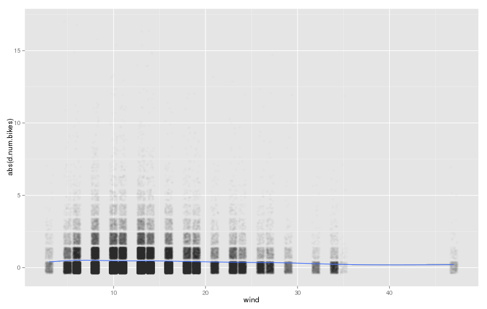

```
##
##  Pearson's product-moment correlation
##
## data:  bikes$wind and abs(bikes$d.num.bikes)
## t = -22.389, df = 173250, p-value < 2.2e-16
## alternative hypothesis: true correlation is not equal to 0
## 95 percent confidence interval:
##  -0.05840721 -0.04901677
## sample estimates:
##         cor
## -0.05371317
```

Unlike rain, it seems that fog, wind and temperature make approximately no difference. The mean absolute difference in number of bikes is about the same regardless of fog, and the correlation between that and temperature/wind is close to zero.

#### Number of bikes at any given time, depending on rain:

[figure not shown]

Rain reduces the variance, with fewer bikes during office hours and more outside of them.